# R Reference

### 3.2.2 Quick plots with `qplot`

`qplot` provides a wrapper for creating ggplots that:

- Is more convenient to use quickly
- Has most (but not all) features in day-to-day use
- Creates a `ggplot` object, so can be manipulated (i.e. additively) in the same way

Note that unlike `plot()` from base-R, `qplot` does *not* accept formula notation!

```r
qplot(displ, hwy, data = mpg, main = "Title here", xlab = "x-axis label") # basic structure
qplot(displ, hwy, data = mpg, facets = ~ class) # faceting: use either a one- or two-sided formula

qplot(displ, hwy, data = mpg, color = class) # same graph as before, much less code!
qplot(displ, hwy, data = mpg, color = I("red")) # surround in I() to set aesthetic

qplot(displ, hwy, data = mpg, geom = c("point", "smooth", "jitter")) # multiple geoms (with jitter)

qplot(hwy, data = mpg) # only specify x creates histogram
qplot(y = hwy, data = mpg, geom = "boxplot") # only specify x creates histogram
```

### 3.2.3 Fonts and customization

See here: https://www.andrewheiss.com/blog/2017/09/27/working-with-r-cairo-graphics-custom-fonts-and-ggplot/

## 3.3 Interactive plots using `plotly`

## 3.4 Interactive plots using `shiny`

# 4 Statistics

## 4.1 Normality

Generally, use the normal quantile plot fom `car`:

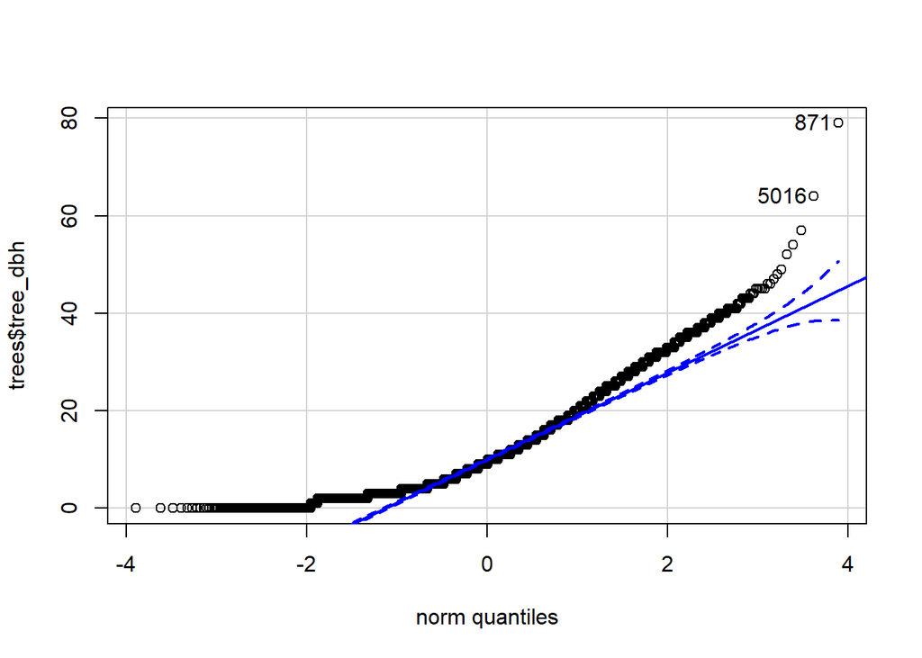

```
## [1]  871 5016
```

```r
require(car)
car::qqPlot(trees$tree_dbh)
```

## 4.2 Transformations

### 4.2.1 Box-Cox transformation

Use either one of these functions, both in the `car` package:

- `car::boxCox` generates a plot on creation, even when assigning to an object
- `car::powerTransform` finds per-column Box-Cox powers (and includes several transformation options. `car::bcPower` raises each column of data to each specified value of `lambda`.

```r
boxcox <- car::boxCox(name_of_model) # generates plot
power <- boxcox$x[which.max(boxcox$y)]

# For multiple columns at once
bc_param <- car::powerTransform(data)
df_new <- bcPower(data, bc_param$lambda)

# bc_param <- car::powerTransform(data, family = "bcPower") -- default
# bc_param <- car::powerTransform(data, family = "bcnPower") -- allows negatives
```

### 4.2.2 Logit transformation

## 4.3 Heteroskedasticity

### 4.3.1 Bartlett’s test for equality of variances

Bartlett’s test assumes data **come from a normal distribution within each group**

- In general, a very sensitive test, so use with a grain of salt
- Very sensitive to departures from non-normality, so if data is non-normal, Barlett’s test might just be testing for that instead
- Note that the *null hypothesis* is $H_0: \text{variances are equal}$, so we actually want to *fail to reject* the null
  - We’ve technically only concluded that we *don’t know that the variances aren’t different*, but in practice we ignore this distinction

```r
bartlett.test(trees$tree_dbh, trees$borough)
```

```
##
##  Bartlett test of homogeneity of variances
##
## data:  trees$tree_dbh and trees$borough
## Bartlett's K-squared = 441.91, df = 4, p-value < 2.2e-16
```

```r
bartlett.test(tree_dbh ~ borough, data = trees) # same thing
```

```
##
##  Bartlett test of homogeneity of variances
##
## data:  tree_dbh by borough
## Bartlett's K-squared = 441.91, df = 4, p-value < 2.2e-16
```

### 4.3.2 Levene’s test for equality of variances

Levene’s test is similar, but doesn’t assume normality within each group (but has lower power):

```r
car::leveneTest(trees$tree_dbh, trees$borough)
```

```
## Levene's Test for Homogeneity of Variance (center = median)
##         Df F value    Pr(>F)
## group    4  90.561 < 2.2e-16 ***
##       9995
## ---
## Signif. codes:  0 '***' 0.001 '**' 0.01 '*' 0.05 '.' 0.1 ' ' 1
```

```r
car::leveneTest(tree_dbh ~ borough, data = trees) # same thing
```

```
## Levene's Test for Homogeneity of Variance (center = median)
##         Df F value    Pr(>F)
## group    4  90.561 < 2.2e-16 ***
##       9995
## ---
## Signif. codes:  0 '***' 0.001 '**' 0.01 '*' 0.05 '.' 0.1 ' ' 1
```

### 4.3.3 Equality of covariances for multivariate tests (Box’s M)

Compute covariance matrices for each group, or use `boxM()` from `biotools`.

```r
for(name in levels(sensing$Crop)) { # loop through categories of factor variable
  print(cov(sensing[sensing$Crop == name, -1]))
}

#s: boxM(predictors, response)
biotools::boxM(data[, -1], data$Crop)
```

## 4.4 Basic hypothesis tests

### 4.4.1 Simple *t*-test for means

```r
# Generate data
n <- 100
rand <- data.frame(id = 1:n,
                   group = sample(1:2, 100, replace = TRUE),
                   var1 = runif(n, -10, 10),
                   var2 = runif(n, -8, 12))
head(rand)
```

```
##   id group       var1       var2
## 1  1     1 -5.2025253  4.0520755
## 2  2     1 -0.3507774 -4.6487709
## 3  3     2  4.5811925  9.7107064
## 4  4     2 -0.4222238  9.4746105
## 5  5     1 -2.8241554 10.4507917
## 6  6     1  0.9294305 -0.9094015
```

```r
# One-sample t-test
t.test(rand$var1) # tests if equal to 0
```

```
##
##  One Sample t-test
##
## data:  rand$var1
## t = -0.36117, df = 99, p-value = 0.7187
## alternative hypothesis: true mean is not equal to 0
## 95 percent confidence interval:
##  -1.3157912  0.9105532
## sample estimates:
## mean of x
## -0.202619
```

```r
t.test(rand$var1, mu = 2, conf.level = 0.99) # tests if equal to 2
```

```
##
##  One Sample t-test
##
## data:  rand$var1
## t = -3.9261, df = 99, p-value = 0.0001596
## alternative hypothesis: true mean is not equal to 2
## 99 percent confidence interval:
##  -1.676068  1.270830
## sample estimates:
## mean of x
## -0.202619
```

```r
# Two-sample t-test, paired
t.test(rand$var1, rand$var2, paired = TRUE)
```

```
##
##  Paired t-test
##
## data:  rand$var1 and rand$var2
## t = -2.1521, df = 99, p-value = 0.03382
## alternative hypothesis: true difference in means is not equal to 0
## 95 percent confidence interval:
##  -3.4609316 -0.1404602
## sample estimates:
## mean of the differences
##               -1.800696
```

```r
# Two-sample t-test, unpaired
t.test(var1 ~ group, data = rand)
```

```
##
##  Welch Two Sample t-test
##
## data:  var1 by group
## t = 1.6455, df = 96.646, p-value = 0.1031
## alternative hypothesis: true difference in means is not equal to 0
## 95 percent confidence interval:
##  -0.3764253  4.0268413
## sample estimates:
## mean in group 1 mean in group 2
##       0.7282371      -1.0969709
```

## 4.5 Bootstrap

## 4.6 Permutation tests

## 4.7 Cross-validation

Base R `sample()` function syntax: `sample(from, n, replace = FALSE)`

# 5 Generalized linear models

## 5.1 Multiple regression

### 5.1.1 Creating the model

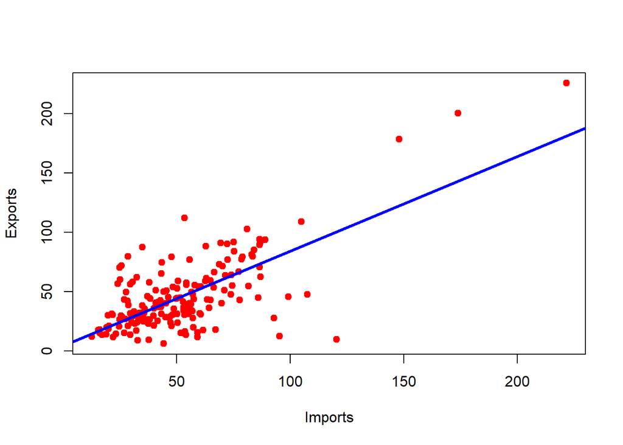

```r
# Create basic model using lm
wb_lm <- lm(Exports ~ Imports, data = wb)

# Plot with regression line
par(mar = c(5.1, 4.1, 4.1, 2.1)) # default R settings
plot(Exports ~ Imports, data = wb, col = "red", pch = 19)
abline(wb_lm$coef, col = "blue", lwd = 3)
```

```r
# Create confidence intervals
confint(wb_lm) # create for all estimates
```

```
##                  2.5 %     97.5 %
## (Intercept) -2.4905683 11.4080643
## Imports      0.6779293  0.9149728
```

```r
confint(wb_lm, "Imports", level = 0.95) # specify which estimates or a conf level
```

```
##             2.5 %    97.5 %
## Imports 0.6779293 0.9149728
```

### 5.1.2 Model diagnostics

By default, `plot()` creates four plots when applied to an `lm` object:

```r
plot(wb_lm) # press 'return' to go through them
plot(wb_lm, which = 1) # print only the residuals vs fits plot
plot(wb_lm, which = 2) # normal quantile plot only

# Better normal quantile plot in car package
car::qqPlot(wb_lm$residuals)
```

### 5.1.3 Robust standard error

After creating a linear model using standard base R `lm`, use:

```r
lmtest::coeftest(lm, vcov = sandwich::vcovHC(lm, type = "HC1"))
```

*Note:* default for type is “HC3”, but must set to “HC1” to obtain same results as Stata

TODO: look more into the `rlm()` functions in `MASS`

### 5.1.4 Joint hypothesis tests

After creating a linear model, use `car::linearHypothesis()`:

```r
car::linearHypothesis(lm, c("meduc = 0", "feduc = 0")) # homoskedastic only
car::linearHypothesis(lm, c("meduc = 0", "feduc = 0"), white.adjust = "hc1") # robust
```

TODO: look more into options in `car::linearHypothesis()`

## 5.2 Analysis of variance

### 5.2.1 ANOVA-regression equivalence

Since ANOVA is essentially the same as linear regression with categorical predictors, many of the methods are similar:

```r
trees_anova <- aov(tree_dbh ~ borough, data = trees)
summary(trees_anova)
```

```
##               Df Sum Sq Mean Sq F value Pr(>F)
## borough        4  20771    5193   72.72 <2e-16 ***
## Residuals   9995 713742      71
## ---
## Signif. codes:  0 '***' 0.001 '**' 0.01 '*' 0.05 '.' 0.1 ' ' 1
```

```r
summary.lm(trees_anova)
```

```
##
## Call:
## aov(formula = tree_dbh ~ borough, data = trees)
##
## Residuals:
##     Min      1Q  Median      3Q     Max
## -12.709  -6.495  -1.709   4.513  67.103
##
## Coefficients:
##                      Estimate Std. Error t value Pr(>|t|)
## (Intercept)            9.4617     0.2362  40.059  < 2e-16 ***
## boroughBrooklyn        2.4348     0.2911   8.363  < 2e-16 ***
## boroughManhattan      -0.9663     0.3578  -2.701  0.00693 **
## boroughQueens          3.2474     0.2742  11.842  < 2e-16 ***
## boroughStaten Island   1.2648     0.3175   3.984 6.82e-05 ***
## ---
## Signif. codes:  0 '***' 0.001 '**' 0.01 '*' 0.05 '.' 0.1 ' ' 1
##
## Residual standard error: 8.45 on 9995 degrees of freedom
## Multiple R-squared:  0.02828,    Adjusted R-squared:  0.02789
## F-statistic: 72.72 on 4 and 9995 DF,  p-value: < 2.2e-16
```

```r
trees_lm <- lm(tree_dbh ~ borough, data = trees)
summary(trees_lm)
```

```
##
## Call:
## lm(formula = tree_dbh ~ borough, data = trees)
##
## Residuals:
##     Min      1Q  Median      3Q     Max
## -12.709  -6.495  -1.709   4.513  67.103
##
## Coefficients:
##                      Estimate Std. Error t value Pr(>|t|)
## (Intercept)            9.4617     0.2362  40.059  < 2e-16 ***
## boroughBrooklyn        2.4348     0.2911   8.363  < 2e-16 ***
## boroughManhattan      -0.9663     0.3578  -2.701  0.00693 **
## boroughQueens          3.2474     0.2742  11.842  < 2e-16 ***
## boroughStaten Island   1.2648     0.3175   3.984 6.82e-05 ***
## ---
## Signif. codes:  0 '***' 0.001 '**' 0.01 '*' 0.05 '.' 0.1 ' ' 1
##
## Residual standard error: 8.45 on 9995 degrees of freedom
## Multiple R-squared:  0.02828,    Adjusted R-squared:  0.02789
## F-statistic: 72.72 on 4 and 9995 DF,  p-value: < 2.2e-16
```

```r
summary.aov(trees_lm)
```

```
##               Df Sum Sq Mean Sq F value Pr(>F)
## borough        4  20771    5193   72.72 <2e-16 ***
## Residuals   9995 713742      71
## ---
## Signif. codes:  0 '***' 0.001 '**' 0.01 '*' 0.05 '.' 0.1 ' ' 1
```

- By default, calling `summary()` on an `aov` object calls `summary.aov()` (which prints the usual ANOVA-style sum of squares output), but we can also force R to print regression-like output for an ANOVA model by calling `summary.lm()` on an `aov` object
- Can do the same for `lm` by calling `summary.aov()` on an `lm` object

### 5.2.2 Confidence intervals for group means

We can actually tell R to fit a regression model *where the coefficient estimates are the group means* by fitting a model *without an intercept*, which we do by adding `-1` to the regression specification:

- We can do this when we have only one categorical predictor since the base level essentially “replaces” the intercept, using up the degree of freedom that the intercept previously used
- Then, the `coef()` function returns the means, and `confint()` returns confidence intervals

```r
trees_lm2 <- lm(tree_dbh ~ borough - 1, data = trees)
coef(trees_lm2) # same as tapply(trees$tree_dbh, trees$borough, mean)
```

```
##         boroughBronx      boroughBrooklyn     boroughManhattan
##             9.461719            11.896552             8.495450
##        boroughQueens boroughStaten Island
##            12.709160            10.726528
```

```r
round(confint(trees_lm2), 2) # 95% CI for individual group means
```

```
##                      2.5 % 97.5 %
## boroughBronx          9.00   9.92
## boroughBrooklyn      11.56  12.23
## boroughManhattan      7.97   9.02
## boroughQueens        12.44  12.98
## boroughStaten Island 10.31  11.14
```

`plotCI()` from `plotrix` can help in plotting confidence intervals:

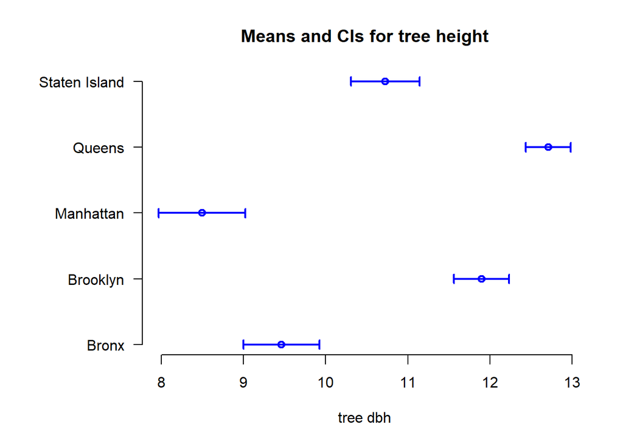

```r
trees_means <- coef(trees_lm2)
trees_ci <- confint(trees_lm2)

par(mar = c(5, 8, 4, 2))
plotrix::plotCI(x = trees_means, # x-values (coef estimates)
                y = 1:length(trees_means), # y-values (just 1 through 5)
                ui = trees_ci[, 2], # upper bound of each error bar
                li = trees_ci[, 1], # lower bound of each error bar
                err = "x", # direction of bars (x is horizontal)
                xlab = "tree dbh", ylab = "", main = "Means and CIs for tree height",
                axes = FALSE, lwd = 2, col = "blue")
axis(side = 1)
axis(side = 2, at = 1:(length(trees_means)), label = levels(trees$borough), las = 2)
```

### 5.2.3 Multiple comparisons

Best way to perform multiple comparisons is using Tukey HSD:

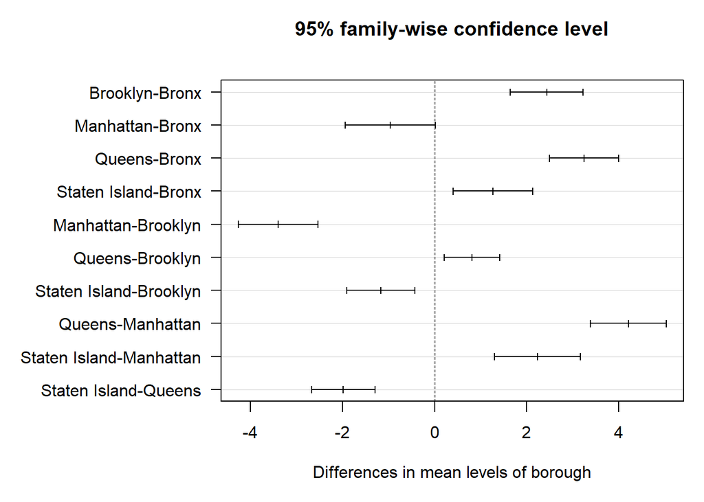

```r
trees_tukey <- TukeyHSD(trees_anova, conf.level = 0.95)

par(mar = c(5, 11, 4, 1))
plot(trees_tukey, las = 1)
```

Alternatively, use `pairwise.t.test()` with different options:

```r
pairwise.t.test(trees$tree_dbh, trees$borough, "none")
```

```
##
##  Pairwise comparisons using t tests with pooled SD
##
## data:  trees$tree_dbh and trees$borough
##
##               Bronx   Brooklyn Manhattan Queens
## Brooklyn      < 2e-16 -        -         -
## Manhattan     0.00693 < 2e-16  -         -
## Queens        < 2e-16 0.00022  < 2e-16   -
## Staten Island 6.8e-05 1.7e-05  7.5e-11   6.2e-15
##
## P value adjustment method: none
```

```r
pairwise.t.test(trees$tree_dbh, trees$borough, "bonferroni")
```

```
##
##  Pairwise comparisons using t tests with pooled SD
##
## data:  trees$tree_dbh and trees$borough
##
##               Bronx   Brooklyn Manhattan Queens
## Brooklyn      6.9e-16 -        -         -
## Manhattan     0.06927 < 2e-16  -         -
## Queens        < 2e-16 0.00222  < 2e-16   -
## Staten Island 0.00068 0.00017  7.5e-10   6.2e-14
##
## P value adjustment method: bonferroni
```

### 5.2.4 Welch’s ANOVA for unequal variances

Assumes unequal variances, but normal distribution within each group.

```r
oneway.test(tree_dbh ~ borough, data = trees)
```

```
##
##  One-way analysis of means (not assuming equal variances)
##
## data:  tree_dbh and borough
## F = 104.7, num df = 4.0, denom df = 3935.2, p-value < 2.2e-16
```

```r
# note: doesn't really have a summary() function
```

### 5.2.5 Kruskal-Wallis test (nonparametric ANOVA)

Makes no assumptions about equality of variance or normality within groups.

```r
kruskal.test(tree_dbh ~ borough, data = trees)
```

```
##
##  Kruskal-Wallis rank sum test
##
## data:  tree_dbh by borough
## Kruskal-Wallis chi-squared = 219.9, df = 4, p-value < 2.2e-16
```

### 5.2.6 Two-way ANOVA

In general, just use same notation as before, but add a factor in the formula:

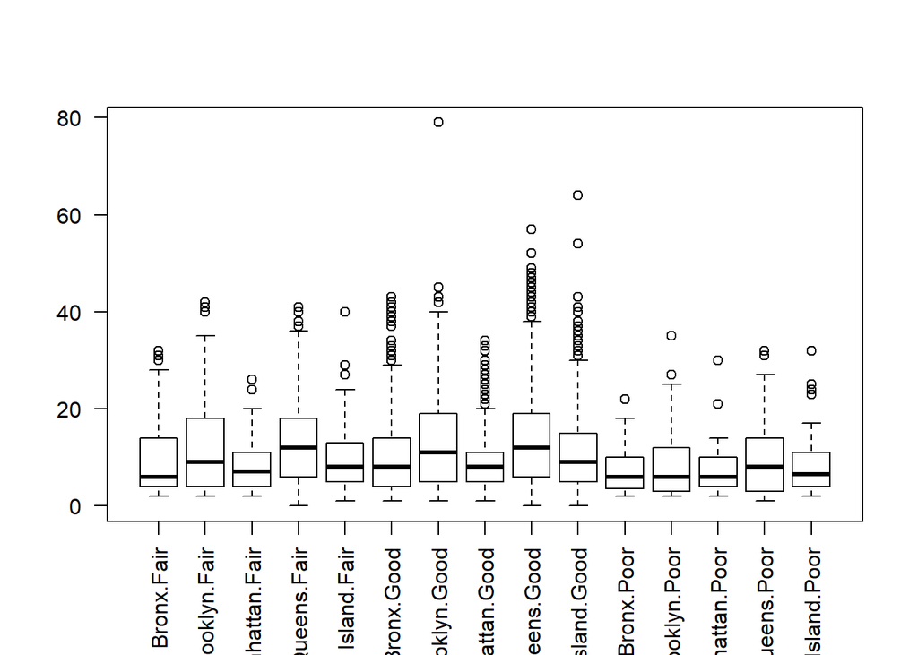

```r
# Cleaning (some of them are the empty string)
levels(trees$health)[1] <- NA

# Make boxplot
boxplot(tree_dbh ~ borough + health, data = trees, las = 2)
```

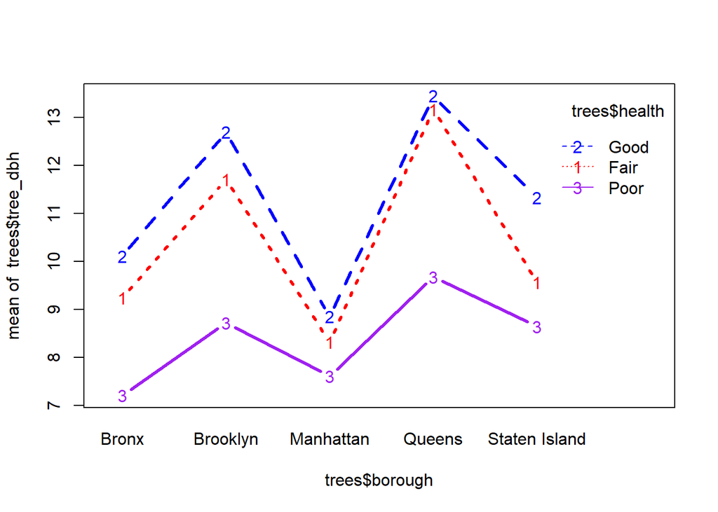

```r
# Interaction plots (does not accept formula notation)
interaction.plot(trees$borough, trees$health, trees$tree_dbh,
                 type = "b", # adds numbers to each line
                 lwd = 3, col = c("red", "blue", "purple"))
```

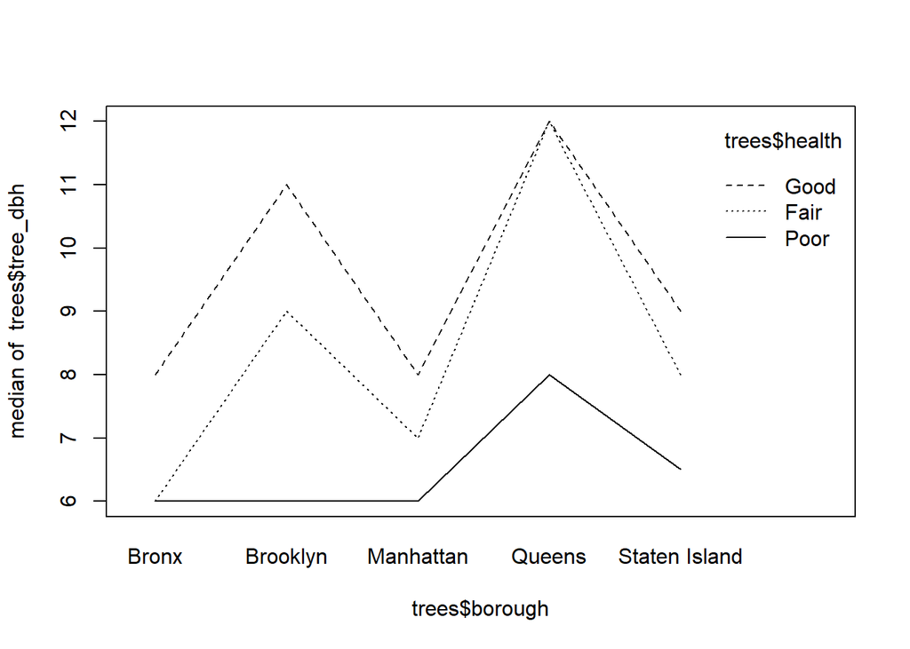

```r
interaction.plot(trees$borough, trees$health, trees$tree_dbh,
                 fun = median) # can use another function
```

```r
# Fit two-way ANOVA
trees_anova2 <- aov(tree_dbh ~ borough + health + borough*health, data = trees)
summary(trees_anova2)
```

```
##                  Df Sum Sq Mean Sq F value   Pr(>F)
## borough           4  22619    5655  81.486  < 2e-16 ***
## health            2   4621    2311  33.296 3.89e-15 ***
## borough:health    8    627      78   1.129     0.34
## Residuals      9533 661545      69
## ---
## Signif. codes:  0 '***' 0.001 '**' 0.01 '*' 0.05 '.' 0.1 ' ' 1
## 452 observations deleted due to missingness
```

For pairwise mean comparisons, create a combination variable for the factors, then fit a one-way ANOVA and use Tukey/pairwise comparisons from there:

```r
trees$boro_health <- as.factor(paste0(trees$borough, "/", trees$health))
trees_anova3 <- aov(tree_dbh ~ boro_health, data = trees)
TukeyHSD(trees_anova3)
```

## 5.3 Mixed continuous and categorical predictors

## 5.4 Multivariate analysis of variance (MANOVA/MANCOVA)

# 6 Dimensionality reduction

## 6.1 Principal component analysis

## 6.2 Factor analysis

# 7 Classification and clustering

Recall that:

[output not shown]

Then we define the following measures:

- **Accuracy** = (TP + TN) / total
- **Specificity** = Type I error rate = FP / (TN + FP)
- **Recall** (power, sensitivity) = 1 - Type II error rate = TP / (FN + TP)
- **Precision** = TP / (TP + FP)

## 7.1 Logistic regression

Use `glm()` with `family = binomial` to fit the model:

```r
flights <- flights %>%
  na.omit() %>%
  mutate(legacy_carrier = carrier %in% c("UA", "DL", "AA"))

sample <- sample(1:nrow(flights), 0.8 * nrow(flights))
flights_train <- flights[sample, ]
flights_test <- flights[-sample, ]

flights_logreg <- glm(legacy_carrier ~ dep_delay + arr_delay,
                      data = flights_train,
                      family = binomial)
summary(flights_logreg)
```

```
##
## Call:
## glm(formula = legacy_carrier ~ dep_delay + arr_delay, family = binomial,
##     data = flights_train)
##
## Deviance Residuals:
##     Min       1Q   Median       3Q      Max
## -1.4654  -1.0590  -0.9388   1.2651   2.4809
##
## Coefficients:
##               Estimate Std. Error z value Pr(>|z|)
## (Intercept) -0.3717001  0.0044561  -83.41   <2e-16 ***
## dep_delay    0.0110584  0.0002596   42.59   <2e-16 ***
## arr_delay   -0.0134753  0.0002347  -57.41   <2e-16 ***
## ---
## Signif. codes:  0 '***' 0.001 '**' 0.01 '*' 0.05 '.' 0.1 ' ' 1
##
## (Dispersion parameter for binomial family taken to be 1)
##
##     Null deviance: 356460  on 261875  degrees of freedom
## Residual deviance: 352344  on 261873  degrees of freedom
## AIC: 352350
##
## Number of Fisher Scoring iterations: 4
```

```r
summary(flights_logreg)$coef # just a table, so can subset columns too
```

```
##                Estimate   Std. Error   z value Pr(>|z|)
## (Intercept) -0.37170008 0.0044561457 -83.41291        0
## dep_delay    0.01105837 0.0002596454  42.59026        0
## arr_delay   -0.01347533 0.0002346992 -57.41534        0
```

```r
coef(flights_logreg)
```

```
## (Intercept)   dep_delay   arr_delay
## -0.37170008  0.01105837 -0.01347533
```

```r
contrasts(flights$legacy_carrier) # find what category R made for the indicator
```

```
##       TRUE
## FALSE    0
## TRUE     1
```

Then use `predict(model_name, newdata, type = "response")` to find the predicted values:

```r
legacy_prob <- predict(flights_logreg,
                       type = "response") # predict probabilities from original dataset
legacy_pred <- legacy_prob > 0.5

(confusion_matrix <- table(flights_train$legacy_carrier, legacy_pred)) # confusion matrix
```

```
##        legacy_pred
##          FALSE   TRUE
##   FALSE 145329   6317
##   TRUE   98555  11675
```

```r
round(sum(diag(prop.table(confusion_matrix))), 3) # accuracy rate
```

```
## [1] 0.6
```

```r
# NOW USE TEST DATA
legacy_prob_test <- predict(flights_logreg,
                            newdata = flights_test, # note newdata argument
                            type = "response")
legacy_pred_test <- legacy_prob_test > 0.5

(confusion_matrix_test <- table(flights_test$legacy_carrier, legacy_pred_test)) # confusion matrix
```

```
##        legacy_pred_test
##         FALSE  TRUE
##   FALSE 36665  1648
##   TRUE  24289  2868
```

```r
round(sum(diag(prop.table(confusion_matrix_test))), 3) # accuracy rate
```

```
## [1] 0.604
```

## 7.2 Discriminant analysis

**Basic discriminant analysis.** Use `lda()` from `MASS`, with either a formula or explicit columns:

```r
require(MASS)
bc_param <- car::powerTransform(sensing[, -1])
sensing[, -1] <- car::bcPower(sensing[, -1], bc_param$lambda)

crop_lda <- lda(Crop ~ x4 + x1, sensing) # LDA with formula
# crop_lda <- lda(sensing[, -1], sensing$Crop) # LDA with explicit columns
crop_qda <- qda(Crop ~ x1 + x2, sensing) # QDA with formula
```

**Classification.** Use `predict()` on an `lda` object (consult `?predict.lda()` for help):

- `predict(da_model)$class` contains predicted classes
- `predict(da_model)$posterior` contains posterior probabilities

```r
predict(crop_lda)$class # contains predicted classes
predict(crop_lda)$posterior # contains posterior probabilities
```

```r
confusion_matrix <- table(sensing$Crop, predict(crop_lda)$class) # confusion matrix
confusion_matrix
```

```
##
##              Clover Corn Cotton Soybeans Sugarbeets
##   Clover         10    1      0        0          0
##   Corn            0    7      0        0          0
##   Cotton          6    0      0        0          0
##   Soybeans        2    1      0        2          1
##   Sugarbeets      3    0      0        1          2
```

```r
round(sum(diag(prop.table(confusion_matrix))), 2) # accuracy rate
```

```
## [1] 0.58
```

**Cross-validation.** Use `lda()` with a separate argument `CV = TRUE`:

```r
crop_lda_cv <- lda(Crop ~ x4 + x1, sensing, CV = TRUE) # LOOCV by default
crop_lda_cv$class # the cv'd lda object already has predicted class labels
crop_lda_cv$posterior # also contains posterior probabilities
```

**Stepwise DA.** Use `stepclass()` from `klaR`, which will output the best model and the correctness rate:

- `method` argument: either `"qda"`, `"lda"`, or other classification process
- `direction` argument: default `"both"`, else `"forward"` or `"backward"`

```r
klaR::stepclass(Crop ~ ., sensing, method = "lda", direction = "both", fold = nrow(sensing))
klaR::stepclass(Crop ~ ., sensing, method = "qda", direction = "forward", fold = nrow(sensing))
```

**Visualization.** Use `partimat()` from `klaR` for partition plots, base R/ggplot for score plots.

- `lda_model$scaling` contains loadings for the discriminant function, but **only for LDA**
- Can use matrix multiplication to obtain scores, then plot

```r
klaR::partimat(Crop ~ x4 + x1, sensing, method = "lda")
klaR::partimat(Crop ~ x1 + x2, sensing, method= "qda")

qda_scores <- data.frame(as.matrix(sensing[,c(5, 2)]) %*% crop_lda$scaling,
                                   ncol = 2, byrow = FALSE)
qda_scores$actual <- sensing$Crop
qplot(LD1, LD2, data = qda_scores, color = actual)
```

## 7.3 k-nearest neighbors

There are several functions from the `FNN` package for k-nearest neighbors:

- `FNN::knn(train, test, class_vector, k)`: for each element in `test`, finds the `k` nearest neighbors in `train`, takes the corresponding values in `class`, and assigns based on majority vote
- `FNN::knn.cv(train, class_vector, k)`: for each element in `train`, takes the element out (performs LOOCV), finds the `k` nearest remaining neighbors in `train`, and assigns majority vote from `class`
- `FNN::knn.reg(train, test = NULL, y, k)`: same as `knn()`, but for quantitative response variable
  - If `test` is not supplied, performs LOOCV
  - Make sure to name the `y` and `k` arguments

Note that we have to separate out the class vectors first for all of these!

## 7.4 k-means clustering

## 7.5 Hierarchical clustering

# 8 Machine learning

## 8.1 Decision trees (CART)

## 8.2 Support vector machines (SVM)

## 8.3 Ensemble methods

# 9 Natural language processing

## 9.1 Packages for dealing with text

## 9.2 Topic models

## 9.3 Sentiment analysis